```python
%matplotlib notebook
import numpy as np
from numpy import sin, pi
from numpy import array, dot, tan, log
np.set_printoptions(precision=4, suppress=True)

import matplotlib.pyplot as plt
from mpl_toolkits.mplot3d import Axes3D
plt.rc('font',**{'family':'sans-serif','sans-serif':['Helvetica']})
plt.rc('text', usetex=True)
```

# Методы решения задач для эллиптических уравнений

## Постановка задачи

Задача Дирихле для эллиптического уравнения Пуассона имеет следующий вид:

$$\frac{\partial^2{u}}{\partial{x}^2} + \frac{\partial^2{u}}{\partial{y}^2} = f(x, y), (x, y)\in (0;1)^2,\\ \begin{align} u \rvert_{x=0}&=\varphi_1(y), &u\rvert_{x=1}=&\varphi_2(y),\\ u \rvert_{y=0}&=\psi_1(x), &u\rvert_{y=1}=&\psi_2(x). \end{align} \tag{1}$$

В дальнейшем мы рассматриваем частный случай - уравнение Лапласа - для которого $f\equiv0$. Заданные нам краевые условия имеют следующий вид:

$$\begin{align} u \rvert_{x=0}&=\varphi_1(y)\equiv0, &u\rvert_{x=1}=&\varphi_2(y)\equiv \sin{\pi y},\\ u \rvert_{y=0}&=\psi_1(x)\equiv \sin{2\pi x}, &u\rvert_{y=1}=&\psi_2(x)\equiv0. \end{align} \tag{2} $$

```python
phi1 = np.zeros_like
phi2 = lambda y: sin(pi*y)
psi1 = lambda x: sin(2*pi*x)
psi2 = np.zeros_like
f = lambda x, y: np.zeros_like(x)

a, b, c, d = 0, 1, 0, 1
```

## Точное решение методом Фурье

Будем искать решение уравнения Лапласа с краевыми условиями (2) в виде $u(x, y)=u_1(x, y)+u_2(x, y)$, где $u_1$ и $u_2$ являются решениями соответствующих стандартных задач:

$$\frac{\partial^2{u_1}}{\partial{x}^2} + \frac{\partial^2{u_1}}{\partial{y}^2} = 0, (x, y)\in (0;1)^2,\\ \begin{align} u_1 \rvert_{x=0}&=0, &u_1\rvert_{x=1}=&0,\\ u_1 \rvert_{y=0}&=\sin{2\pi x}, &u_1\rvert_{y=1}=&0; \end{align}$$$$\frac{\partial^2{u_2}}{\partial{x}^2} + \frac{\partial^2{u_2}}{\partial{y}^2} = 0, (x, y)\in (0;1)^2,\\ \begin{align} u_2 \rvert_{x=0}&=0, &u_2\rvert_{x=1}=&\sin{\pi y},\\ u_2 \rvert_{y=0}&=0, &u_2\rvert_{y=1}=&0. \end{align}$$

Решение первой стандартной задачи с неопределёнными коэффициентами:

$$ u_1(x, y) \equiv \sum\limits_{n=1}^{\infty} (A_n \cosh{\pi n y} + B_n \sinh{\pi n y}) \sin{\pi n x}. $$$$ u_1(x, 0) \equiv \sum\limits_{n=1}^{\infty} A_n \sin{\pi n x} = \sin{2\pi x} \Rightarrow \forall {n \neq 2}\text{ }A_n = 0,\text{ }A_2=1.\\ u_1(x, 1) \equiv \sum\limits_{n=1}^{\infty} (A_n \cosh{\pi n} + B_n \sinh{\pi n}) \sin{\pi n x} = 0 \Rightarrow \forall n\neq 2\text{ }B_n = 0,\text{ }B_2 = -\frac{\cosh{2\pi}}{\sinh{2\pi}}. $$

Окончательно, $$u_1(x, y)=\frac{\sinh{2\pi(1-y)}}{\sinh{2\pi}} \sin{2\pi x}.$$

Решение второй стандартной задачи с неопределёнными коэффициентами:

$$ u_2(x, y) \equiv \sum\limits_{n=1}^{\infty} (С_n \cosh{\pi n x} + D_n \sinh{\pi n x}) \sin{\pi n y} $$$$ u_2(0, y) \equiv \sum\limits_{n=1}^{\infty} C_n \sin{\pi n y} = 0 \Rightarrow \forall n \in \mathbb{N}\text{ }C_n = 0.\\ u_2(1, y) \equiv \sum\limits_{n=1}^{\infty} (C_n \cosh{\pi n} + D_n \sinh{\pi n}) \sin{\pi n y} = \sin{\pi y} \Rightarrow D_1 = \frac{1}{\sinh{\pi}},\text{ }\forall n>1\text{ }D_n = 0. $$

Окончательно, $$u_2(x, y)=\frac{\sinh{\pi x}}{\sinh{\pi}}\sin{\pi y}.$$

Точное решение исходной задачи:

$$ u(x, y) = \frac{\sinh{2\pi(1-y)}}{\sinh{2\pi}} \sin{2\pi x} + \frac{\sinh{\pi x}}{\sinh{\pi}}\sin{\pi y}.$$

```python
def u_true(x, y):
    from numpy import sinh, cosh
    u1 = sinh(2*pi*(1-y)) / sinh(2*pi) * sin(2*pi*x)
    u2 = sinh(pi*x) / sinh(pi) * sin(pi*y)
    return u1 + u2
```

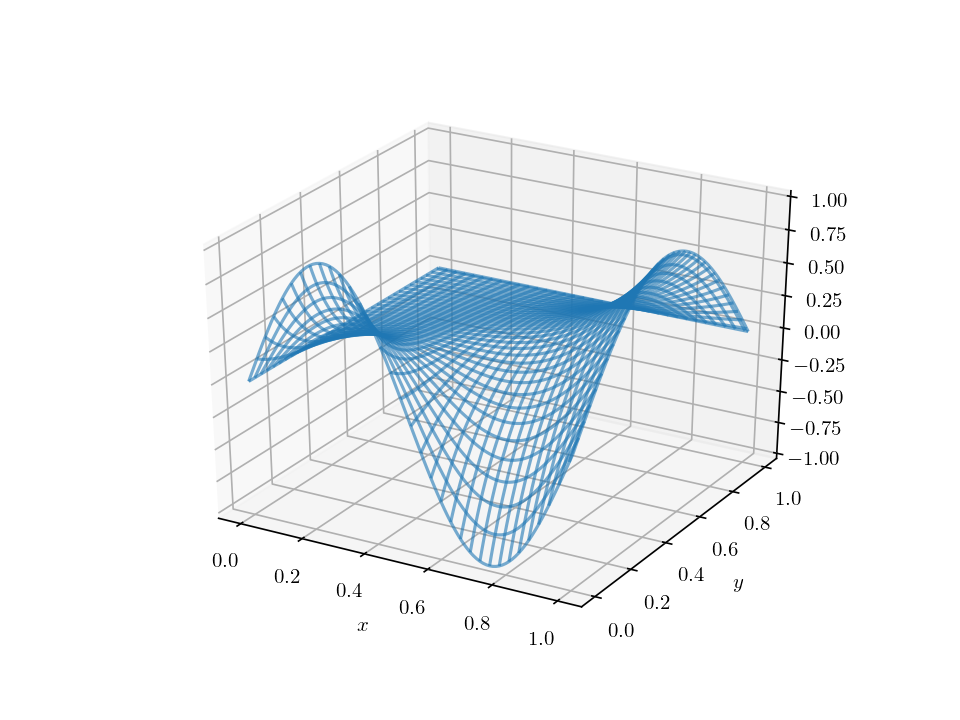

```python
h = 0.01
x_dense = np.linspace(a, b, int(1/h)+1)
y_dense = np.linspace(c, d, int(1/h)+1)
xx_dense, yy_dense = np.meshgrid(x_dense, y_dense)

fig1 = plt.figure()
ax1 = fig1.add_subplot(111, projection='3d')
ax1.plot_wireframe(xx_dense, yy_dense, u_true(xx_dense, yy_dense), alpha=0.6, label='$u(x, y)$')
ax1.set_xlabel('$x$'); ax1.set_ylabel('$y$')
ax1.set_title("Точное решение задачи")
ax1.legend();
```

Сразу напишем функцию для построения графиков.

```python
def plot_solution(uu, xx, yy, u_true, method_name):
    global xx_dense, yy_dense
    h = xx[0, 1] - xx[0, 0]
    fig = plt.figure(figsize=(9, 4))
    ax1 = fig.add_subplot(121, projection='3d')
    ax1.plot_wireframe(xx_dense, yy_dense, u_true(xx_dense, yy_dense), alpha=0.6, label='$u(x, y)$')
    ax1.plot_wireframe(xx, yy, uu, alpha=0.75, color='r', label='$\hat{u}_{%s}(x, y), h=%.1f$' % (method_name, h))
    ax1.scatter(xx, yy, uu, alpha=0.75, s=10, c='r')

    ax2 = fig.add_subplot(122, projection='3d')
    ax2.plot_wireframe(xx, yy, np.abs(uu - u_true(xx, yy)), label='$|\hat{u}_{%s} - u|, h=%.1f$' % (method_name, h))

    for ax in fig.get_axes():
        ax.set_xlabel('$x$'); ax.set_ylabel('$y$')
        ax.legend();
    return fig
```

## Сеточные методы

```python
h1, h2 = 0.2, 0.1
eps = 1e-3
```

```python
x = np.linspace(a, b, int((b-a)/h1)+1)
y = np.linspace(c, d, int((d-c)/h1)+1)
xx, yy = np.meshgrid(x, y)
ff = f(xx, yy)
uu_true = u_true(xx, yy)
```

Значения приближённого решения в граничных точках сетки определим согласно краевым условиям:

$$ u_{i, 0}=\psi_1(x_i), u_{i, N}=\psi_2(x_i),\text{ }i=0, 1, ..., N_x,\\ u_{0, j}=\varphi_1(y_j), u_{N, j}=\varphi_2(y_j),\text{ }j=0, 1, ..., N_y. $$

В нашем случае

$$\begin{align} &u_{i, 0}=\sin{0,4\pi i}, &u_{i, N}=0,\text{ }i=0, 1, ..., 5,\\ &u_{0, j}=0, &u_{N, j}=\sin{0,2\pi j},\text{ }j=0, 1, ..., 5. \end{align}$$

### Шаблон "крест"

Аппроксимация оператора Лапласа во внутренних точках сетки:

$$ \Delta u\rvert_{ij} = \frac{u_{i-1, j} - 2u_{i,j}+u_{i+1, j}}{h_x^2} + \frac{u_{i, j-1} - 2u_{i,j}+u_{i, j+1}}{h_y^2} + O(h_x^2 + h_y^2), i=1, 2,..., N_x-1,\text{ }j=1, 2,..., N_y-1.$$

Запишем уравнение Пуассона во всех внутренних точках сетки, заменив оператор Лапласа таким шаблоном и опустив $O$-слагаемые. Полагая $h_x=h_y=h$, получим такую СЛАУ для нахождения приближённого решения в точках сетки:

$$u_{i, j} = \frac{1}{4}\left(u_{i-1, j} + u_{i, j-1} + u_{i+1, j} + u_{i, j+1}-h^2 f_{ij}\right), \text{ }i,j=1, 2, \dots, N-1$$

.

В нашем случае последнее слагаемое в скобках обнулится и система будет иметь вид

$$u_{i, j} = \frac{1}{4}\left(u_{i-1, j} + u_{i, j-1} + u_{i+1, j} + u_{i, j+1}\right), \text{ }i,j=1, 2, 3, 4\,\\ \begin{align} &u_{i, 0}=\sin{0,4\pi i}, &u_{i, N}=0,\text{ }i=0, 1, ..., 5,\\ &u_{0, j}=0, &u_{N, j}=\sin{0,2\pi j},\text{ }j=0, 1, ..., 5. \end{align} $$

.

### Решение системы методами Якоби и Зейделя

Оба метода являются итерационными (значение приближенного решения на $k+1$-й итерации строится на основании значений приближенного решения на $k$-й итерации, пока изменение всего каркаса не станет достаточно маленьким).

```python
def construct_uu0(phi1, phi2, psi1, psi2, xx, yy):
    uu0 = np.zeros_like(xx)
    x = xx[0]; y = yy[:, 0]; a = x[0]
    interpolate = lambda x, y: phi1(y) + (x-a)*(phi2(y)-phi1(y))
    uu0[:, :] = interpolate(xx[:, :], yy[:, :])
    uu0[0, :] = psi1(x); uu0[-1, :] = psi2(x);
    return uu0

# начальное приближение для 5-шаговой сетки
uu0 = construct_uu0(phi1, phi2, psi1, psi2, xx, yy)
uu0[::-1]
```

```
array([[ 0.    ,  0.    ,  0.    ,  0.    ,  0.    ,  0.    ],
       [ 0.    ,  0.1176,  0.2351,  0.3527,  0.4702,  0.5878],
       [ 0.    ,  0.1902,  0.3804,  0.5706,  0.7608,  0.9511],
       [ 0.    ,  0.1902,  0.3804,  0.5706,  0.7608,  0.9511],
       [ 0.    ,  0.1176,  0.2351,  0.3527,  0.4702,  0.5878],
       [ 0.    ,  0.9511,  0.5878, -0.5878, -0.9511, -0.    ]])
```

Согласно методу Якоби приближенное значение решения на $k+1$-ой итерации можно вычислить с помощью простой формулы:

$$u_{i,j}^{(k+1)} = \frac{1}{4}\left(u_{i-1, j}^{(k)} + u_{i, j-1}^{(k)} + u_{i+1, j}^{(k)} + u_{i+1, j+1}^{(k)}\right), (i,j)\in\{1, 2, \dots, N-1\}^2,$$

то есть значение функции $u$ в каждом внутреннем узле сетки $(x_i, y_j)$ на следующей итерации считается как среднее арифметическое значений соседних узлов на предыдущей итерации.

Для достижения точности аппроксимации $\varepsilon$ необходимо сделать $$n_0(\varepsilon)=\left[\frac{\log{\frac{1}{\varepsilon}}}{\log{\frac{1}{\rho}}}\right]+1$$ итераций, где

$$ \DeclareMathOperator{\tg}{tg} \rho=\frac{1-\xi}{1+\xi}, \xi=\frac{\lambda_{\min}}{\lambda_{\max}}=\tg^2{\frac{\pi h}{2}}.$$

```python
# функция, реализующая вычисление каркаса
# решения на следующей итерации:
def uu_next_jac(uu, ff, h):
    uu_next = uu.copy()
    uu_next[1:-1, 1:-1] = 0.25 * (uu[:-2, 1:-1] + uu[2:, 1:-1] + uu[1:-1, :-2] + uu[1:-1, 2:] - h**2 * ff[1:-1, 1:-1])
    return uu_next

# функция, реализующая вычисление необходимого количества
# итераций для достижения заданной точности при заданном шаге
def get_n_iter_jac(eps, h):
    xi = tan(pi*h/2)**2
    rho = (1-xi) / (1+xi)
    return int(log(1 / eps) / log(1 / rho)) + 1
```

```python
#n_iter_jac = get_n_iter_jac(eps, h1)
uu0 = construct_uu0(phi1, phi2, psi1, psi2, xx, yy)
uu_prev, uu = uu0, uu_next_jac(uu0, ff, h)
n_iter_jac = 1
#for i in range(n_iter_jac):
while np.max(np.abs(uu-uu_prev)) >= eps:
    uu_prev = uu
    uu = uu_next_jac(uu, ff, h)
    n_iter_jac += 1

uu_jac = uu
print('Количество итераций, после которых метод Якоби сошёлся: ', n_iter_jac)
print('Максимальная погрешность каркаса решения: ', np.max(np.abs(uu_true-uu_jac)))
print('Среднеквадратическая погрешность каркаса решения: ', np.linalg.norm(np.abs(uu_true-uu_jac)))
```

```
Количество итераций, после которых метод Якоби сошёлся:  20
Максимальная погрешность каркаса решения:  0.044405255233
Среднеквадратическая погрешность каркаса решения:  0.0840117935081
```

Каркас приближённого решение задачи, построенный для $h=0,2$, СЛАУ решалась методом Якоби:

```python
uu_jac[::-1]
```

```
array([[ 0.    ,  0.    ,  0.    ,  0.    ,  0.    ,  0.    ],
       [ 0.    ,  0.0476,  0.0951,  0.1663,  0.3099,  0.5878],
       [ 0.    ,  0.0943,  0.1645,  0.2585,  0.4842,  0.9511],
       [ 0.    ,  0.1631,  0.207 ,  0.216 ,  0.4154,  0.9511],
       [ 0.    ,  0.3492,  0.2815, -0.02  ,  0.0083,  0.5878],
       [ 0.    ,  0.9511,  0.5878, -0.5878, -0.9511, -0.    ]])
```

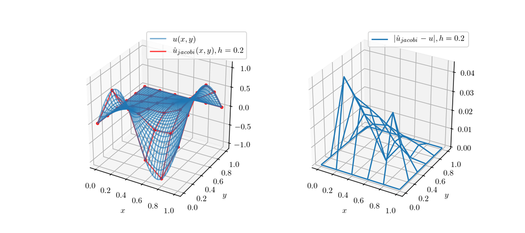

```python
fig2 = plot_solution(uu_jac, xx, yy, u_true, 'jacobi')
```

Для метода Зейделя формула получения каркаса на следующей итерации похожа, однако она предполагает использование не только каркаса на предыдущей итерации, но и тех значений текущего каркаса, что уже посчитаны, чем позволяет немного ускорить сходимость. Формула:

$$u_{i,j}^{(k+1)} = \frac{1}{4}\left(u_{i-1, j}^{(k+1)} + u_{i, j-1}^{(k+1)} + u_{i+1, j}^{(k)} + u_{i+1, j+1}^{(k)}\right), (i,j)\in\{1, 2, \dots, N-1\}^2,$$

Фактически, мы сперва заполним снизу вверх весь первый столбец каркаса, затем точно также второй и так далее (можно также заполнять построчно).

```python
def uu_next_seid(uu, ff, h):
    N = len(uu) - 1
    uu_next = uu.copy()
    for j in range(1, N):
        for i in range(1, N):
            uu_next[i, j] = 0.25 * (uu_next[i-1, j] + uu_next[i, j-1] + uu[i+1, j] + uu[i, j+1] - h**2*ff[i, j])
    return uu_next
```

```python
n_iter_seid = 1
uu0 = construct_uu0(phi1, phi2, psi1, psi2, xx, yy)
uu_prev, uu = uu0, uu_next_seid(uu0, ff, h)
while np.max(np.abs(uu-uu_prev)) >= eps:
    uu_prev = uu
    uu = uu_next_seid(uu, ff, h)
    n_iter_seid += 1

uu_seid = uu
print('Количество итераций, после которых метод Зейделя сошёлся: ', n_iter_seid)
print('Максимальная погрешность каркаса решения: ', np.max(np.abs(uu_seid-uu_true)))
print('Среднеквадратическая погрешность каркаса решения: ', np.linalg.norm(np.abs(uu_true-uu_seid)))
```

```
Количество итераций, после которых метод Зейделя сошёлся:  14
Максимальная погрешность каркаса решения:  0.0436186066719
Среднеквадратическая погрешность каркаса решения:  0.0812757915703
```

Каркас приближённого решение задачи, построенный для $h=0,2$, СЛАУ решалась методом Зейделя:

```python
uu_seid[::-1]
```

```
array([[ 0.    ,  0.    ,  0.    ,  0.    ,  0.    ,  0.    ],
       [ 0.    ,  0.0465,  0.0931,  0.1643,  0.3085,  0.5878],
       [ 0.    ,  0.0926,  0.1615,  0.2553,  0.4821,  0.9511],
       [ 0.    ,  0.1616,  0.2043,  0.213 ,  0.4134,  0.9511],
       [ 0.    ,  0.3484,  0.28  , -0.0217,  0.0072,  0.5878],
       [ 0.    ,  0.9511,  0.5878, -0.5878, -0.9511, -0.    ]])
```

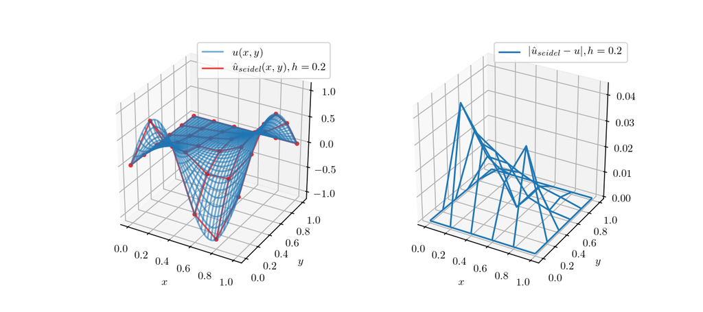

```python
fig3 = plot_solution(uu_seid, xx, yy, u_true, 'seidel')
```

### Метод матричной прогонки

Пусть $I_y$ - единичная матрица размера $N-1$,

$$ \Lambda_y = \frac{1}{h^2} \left[\begin{array}{ccccccc} -2 & 1 & 0 & 0 & \dots & \dots & \dots \\ 1 & -2 & 1 & 0 & \dots & \dots & \dots \\ 0 & 1 & -2 & 1 & \dots & \dots & \dots \\ ...&... &... &...& ... & ... & ... \\ ...&... &... &...& 1 & -2 & 1\\ ...&... &... &...& 0 & 1 & -2 \end{array}\right]. $$

Обозначим в качестве $\mathbf{u}_i$ вектор $\left[u_{i,1}, ..., u_{i, N-1}\right]^T$. Тогда система, к которой мы приходим, может быть сведена к такой:

$$ A_i \mathbf{u}_{i-1} + B_i \mathbf{u}_i + C_i \mathbf{u}_{i+1} = \mathbf{f}_i,$$$$\mathbf{u}_0 = \left[\varphi_1(y_1),\dots,\varphi_1(y_{N-1})\right]^T, \mathbf{u}_N = \left[\varphi_2(y_1),\dots,\varphi_2(y_{N-1})\right]^T,$$

со следующими коэффициентами:

$$ A_0 = C_n = \Theta,\\ A_i = \frac{1}{h^2}I_y, B_i = -\left(\frac{2}{h^2}I_y - \Lambda_y\right), C_i = \frac{1}{h^2}I_y,$$

и такими векторами в правой части:

$$ \mathbf{f}_i = \left[ \begin{array}{ccccc} f_{i,1} - \frac{1}{h^2}\psi_1(x_i) & f_{i, 2} & ... & f_{i, N-2} & f_{i, N-1} - \frac{1}{h^2} \psi_2(x_i) \end{array}\right]^T$$

Систему эту решаем методом матричной прогонки.

В нашем случае эта система будет иметь следующий вид:

$$ \frac{1}{0,2^2}I_y\mathbf{u}_0 - (\frac{2}{0,2^2}-\Lambda_y)\mathbf{u}_1 + \frac{1}{0,2^2}I_y\mathbf{u}_2 = \mathbf{f_1},\\ \frac{1}{0,2^2}I_y\mathbf{u}_1 - (\frac{2}{0,2^2}-\Lambda_y)\mathbf{u}_2 + \frac{1}{0,2^2}I_y\mathbf{u}_3 = \mathbf{f_2},\\ \frac{1}{0,2^2}I_y\mathbf{u}_2 - (\frac{2}{0,2^2}-\Lambda_y)\mathbf{u}_3 + \frac{1}{0,2^2}I_y\mathbf{u}_4 = \mathbf{f_3},\\ \frac{1}{0,2^2}I_y\mathbf{u}_3 - (\frac{2}{0,2^2}-\Lambda_y)\mathbf{u}_4 + \frac{1}{0,2^2}I_y\mathbf{u}_5 = \mathbf{f_4},\\ \mathbf{u}_0 = \left[0, 0, 0, 0\right]^T, \mathbf{u}_5 = \left[\sin{0,2\pi}, \sin{0,4\pi}, \sin{0,6\pi}, \sin{0,8\pi}\right]^T,\\ \mathbf{f}_1 = \left[-\frac{\sin{0,4\pi}}{0,2^2}, 0, 0, 0\right]^T, \mathbf{f}_2 = \left[-\frac{\sin{0,8\pi}}{0,2^2}, 0, 0, 0\right]^T,\\ \mathbf{f}_3 = \left[-\frac{\sin{1,2\pi}}{0,2^2}, 0, 0, 0\right]^T, \mathbf{f}_4 = \left[-\frac{\sin{1,6\pi}}{0,2^2}, 0, 0, 0\right]^T, $$

где $I_y$ и $\Lambda_y$ - описанные выше матрицы размера 4.

```python
N = int(1/h1)
Iy = np.identity(N-1)
Ly = 1 / h1**2 * (np.diag(np.ones(N-2), -1) - 2*Iy + np.diag(np.ones(N-2), 1))
A = 1 / h1**2 * Iy; C = A
B = -(A+C-Ly)

F = np.zeros((N-1, N+1))
F[:, 1:-1] = ff[1:-1, 1:-1]
F[:, 0] = phi1(y[1:-1]); F[:, -1] = phi2(y[1:-1])
F[0, 1:-1] -= psi1(x[1:-1]) / h1**2; F[-1, 1:-1] -= psi2(x[1:-1]) / h1**2
```

```python
from numpy.linalg import inv

P0 = np.zeros_like(B)
q0 = F[:, 0]
P = [P0]
q = [q0]
for i in range(1, N):
    Pi = -dot(inv(B + dot(A, P[i-1])), C); P.append(Pi)
    qi =  dot(inv(B + dot(A, P[i-1])), F[:, i] - dot(A, q[i-1])); q.append(qi)

qN = F[:, -1]
```

```python
uu_thom = uu0
uu_thom[1:-1, N] = qN
for i in range(N-1, 0, -1):
    uu_thom[1:-1, i] = dot(P[i], uu_thom[1:-1, i+1]) + q[i-1]

print('Максимальная погрешность каркаса решения: ', np.max(np.abs(uu_thom-uu_true)))
print('Среднеквадратическая погрешность каркаса решения: ', np.linalg.norm(np.abs(uu_true-uu_thom)))
```

```
Максимальная погрешность каркаса решения:  0.404369572102
Среднеквадратическая погрешность каркаса решения:  0.555431891495
```

Каркас приближённого решение задачи, построенный для $h=0,2$, СЛАУ решалась методом матричной прогонки:

```python
uu_thom[::-1]
```

```
array([[ 0.    ,  0.    ,  0.    ,  0.    ,  0.    ,  0.    ],
       [ 0.    ,  0.0492,  0.1056,  0.1865,  0.3259,  0.5878],
       [ 0.    ,  0.0912,  0.1919,  0.3185,  0.5292,  0.9511],
       [ 0.    ,  0.1238,  0.2678,  0.3743,  0.5214,  0.9511],
       [ 0.    ,  0.1361,  0.4205,  0.4008,  0.2306,  0.5878],
       [ 0.    ,  0.9511,  0.5878, -0.5878, -0.9511, -0.    ]])
```

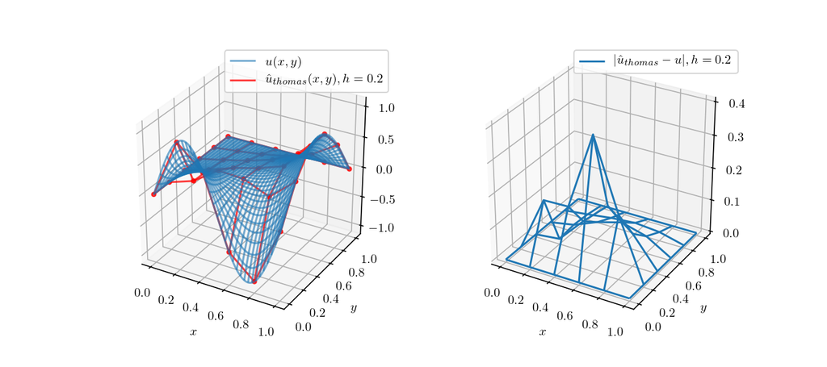

```python
fig4 = plot_solution(uu_thom, xx, yy, u_true, 'thomas')
```

Общая функция для численного решения задачи Дирихле для уравнения Пуассона, в которой система решается одним из трёх заданных методов:

```python
def solve_poisson_bvp(f, bounds, bcs, h, method='seidel', eps=1e-3):

    a, b, c, d = bounds
    phi1, phi2, psi1, psi2 = bcs
    x = np.linspace(a, b, int((b-a)/h)+1)
    y = np.linspace(c, d, int((b-a)/h)+1)
    xx, yy = np.meshgrid(x, y)
    ff = f(xx, yy)
    uu0 = construct_uu0(phi1, phi2, psi1, psi2, xx, yy)

    if method == 'jacobi':
        n_iter_jac = get_n_iter_jac(eps, h)
        uu = uu0
        for i in range(n_iter_jac):
            uu = uu_next_jac(uu, ff, h)
        return uu, n_iter_jac, xx, yy
    elif method == 'seidel':
        n_iter_seid = 1
        uu_prev, uu = uu0, uu_next_seid(uu0, ff, h)
        while np.max(np.abs(uu-uu_prev)) >= eps:
            uu_prev = uu
            uu = uu_next_seid(uu, ff, h)
            n_iter_seid += 1
        return uu, n_iter_seid, xx, yy
    elif method == 'thomas':
        from numpy.linalg import inv
        N = len(x) - 1
        Iy = np.identity(N-1)
        Ly = 1 / h**2 * (np.diag(np.ones(N-2), -1) - 2*Iy + np.diag(np.ones(N-2), 1))
        A = 1 / h**2 * Iy; C = A
        B = -(A+C-Ly)
        F = np.c_[phi1(y[1:-1]), ff[1:-1, 1:-1], phi2(y[1:-1])]
        F[0, 1:-1] -= psi1(x[1:-1]) / h**2; F[-1, 1:-1] -= psi2(x[1:-1]) / h**2
        # прямой ход
        P0 = np.zeros_like(B)
        q0 = F[:, 0]
        P = [P0]
        q = [q0]
        for i in range(1, N):
            Pi = -dot(inv(B + dot(A, P[i-1])), C); P.append(Pi)
            qi =  dot(inv(B + dot(A, P[i-1])), F[:, i] - dot(A, q[i-1])); q.append(qi)
        qN = F[:, -1]
        # обратный ход
        uu_thom = uu0
        uu_thom[1:-1, N] = qN
        for i in range(N-1, 0, -1):
            uu_thom[1:-1, i] = dot(P[i], uu_thom[1:-1, i+1]) + q[i-1]
        return uu_thom, xx, yy
    else: raise ValueError("Inappropriate value for 'method' argument!")
```

```python
uu_jac10, _, xx10, yy10 = solve_poisson_bvp(f, [a, b, c, d], [phi1, phi2, psi1, psi2], h2, 'jacobi')
uu_seid10 = solve_poisson_bvp(f, [a, b, c, d], [phi1, phi2, psi1, psi2], h2, 'seidel')[0]
uu_thom10 = solve_poisson_bvp(f, [a, b, c, d], [phi1, phi2, psi1, psi2], h2, 'thomas')[0]
uu_true10 = u_true(xx10, yy10)
```

График каркаса приближённого решения задачи и погрешности приближения, $h=0,1$, СЛАУ решалась методом Якоби:

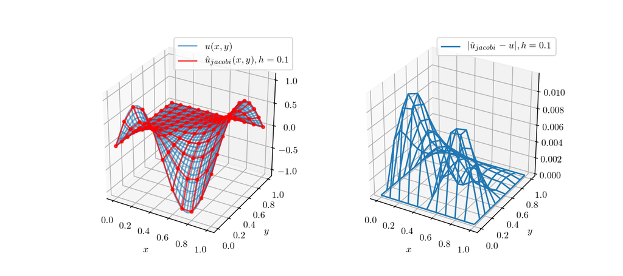

```
Максимальная погрешность каркаса решения:  0.0118806990801
Среднеквадратическая погрешность каркаса решения:  0.0445542564704
```

```python
fig5 = plot_solution(uu_jac10, xx10, yy10, u_true, 'jacobi')
print('Максимальная погрешность каркаса решения: ',
      np.max(np.abs(uu_jac10-uu_true10)))
print('Среднеквадратическая погрешность каркаса решения: ',
      np.linalg.norm(np.abs(uu_jac10-uu_true10)))
```

График каркаса приближённого решения задачи и погрешности приближения, $h=0,1$, СЛАУ решалась методом Зейделя:

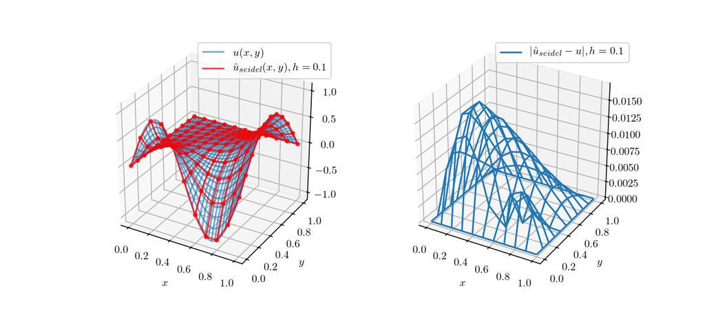

```
Максимальная погрешность каркаса решения:  0.0171688288448
Среднеквадратическая погрешность каркаса решения:  0.0735687841424
```

```python
fig6 = plot_solution(uu_seid10, xx10, yy10, u_true, 'seidel')
print('Максимальная погрешность каркаса решения: ',
      np.max(np.abs(uu_seid10-uu_true10)))
print('Среднеквадратическая погрешность каркаса решения: ',
      np.linalg.norm(np.abs(uu_seid10-uu_true10)))
```

График каркаса приближённого решения задачи и погрешности приближения, $h=0,1$, СЛАУ решалась методом матричной прогонки:

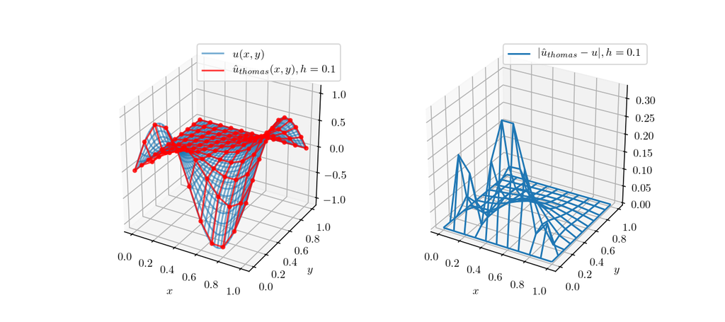

```
Максимальная погрешность каркаса решения:  0.328642917475
Среднеквадратическая погрешность каркаса решения:  0.758591044984
```

```python
fig7 = plot_solution(uu_thom10, xx10, yy10, u_true, 'thomas')
print('Максимальная погрешность каркаса решения: ',
      np.max(np.abs(uu_thom10-uu_true10)))
print('Среднеквадратическая погрешность каркаса решения: ',
      np.linalg.norm(np.abs(uu_thom10-uu_true10)))
```

Уточним теперь значения каркаса приближённого решения, построенного для $h=0,2$, с помощью правила Рунге, согласно которому погрешность приближённого решения $\varepsilon_{i,j}^h$ в точке $(x_i, u_j)$ по сетке с шагом $h$ можно оценить так (учтём, что порядок аппроксимации схемы равен 2):

$$\varepsilon_{i,j}^h = \frac{u_{i,j}^{\frac{h}{2}}-u_{i,j}^h}{1 - 2^{-2}}.$$

```
Максимальная погрешность каркаса приближённого решения после уточнения:  0.011587979307
Среднеквадратическая погрешность уточнённого каркаса решения:  0.0294804442581
```

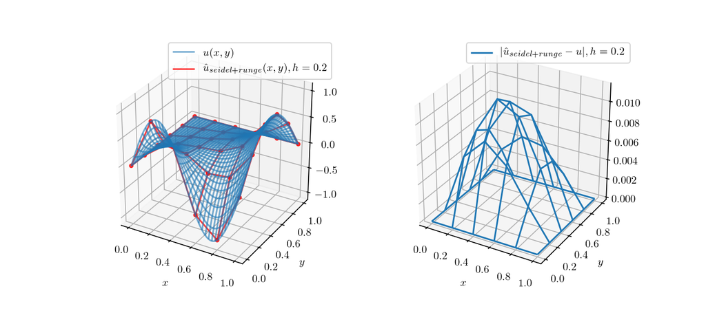

```python
eps = 4/3*(uu_seid10[::2, ::2] - uu_seid)
print('Максимальная погрешность каркаса приближённого решения после уточнения: ',
      np.max(np.abs(uu_seid+eps-uu_true)))
print('Среднеквадратическая погрешность уточнённого каркаса решения: ',
      np.linalg.norm(np.abs(uu_seid+eps-uu_true)))
fig8 = plot_solution(uu_seid+eps, xx, yy, u_true, 'seidel+runge')
```

Видим, что после уточнения погрешность аппроксимации существенно уменьшилась с максимальной 0,043 для каркаса до 0,011.